# License Applications in NYC Analysis

Nikola Baci

2023-02-02

# Introduction

## Data

In this notebook you will be presented with an exploratory analysis of the license applications in the NYC metropolitan area. The data is downloaded from NYC Open Data and it could be found [here](https://data.cityofnewyork.us/Business/License-Applications/ptev-4hud).

## Business Owner

If you want to to open a business and you would like to be one step ahead of your competition, then this analysis is for your. Here you will find out how long on average would take for your to get your license, where your competition is located, how far has your industry has grown and a forecast on where the direction of this growth in the next 2 years.

## DCWP

This analysis is also intended to help the Department of Consumer and Worker Protection (DCWP) on creating an overview of their data and improve their daily and seasonal operations.

# Data and Methods

The data set is retrieved from NYC Open Data which is an evolving set as DCWP is updating it weekly. The data set was made available at first in January 2016 and has grown into almost half a million cases. The data set has over 25 features (columns) but the columns that I paid the most interest in are the license category, date the license was issued as well as the geo-location of the businesses.

This analysis is primary descriptive with the main focus being the understanding patterns and gathering insights on past observations. At the end you will also find a forecasting model for the next 2 years.

# Analysis, Results and Interpretations

## Import the data

The zipcode data is to provide a unified pairing between zipcode and county because counties differ depending on what the applicant wrote which might not be correct.

We also do some cleaning of the column names and subset the data. The data that we will focus is all the licenses that are issued in the 5 boroughs in NYC.

```r
license_applications <-  read.csv("data.csv")
zipcodes <- read.csv("zipcodes.csv")

names(zipcodes) <- tolower(gsub("[.]", "_", names(zipcodes)))
zipcodes <- rename(zipcodes, zip = zip_code, city = common_cities)
zipcodes$zip <- as.character(zipcodes$zip)


df_orig <- license_applications

df_orig <- df_orig %>%
  select(Application.ID:End.Date, License.Category, Application.Category, City:Latitude)

#change names
names(df_orig) <- tolower(gsub("[.]", "_", names(df_orig)))
zipcodes <- select(zipcodes, -type)


df <- df_orig

#Limit the analysis of only businesses in from NY with an valid issued licence
df <- df %>%
  filter(state == "NY") %>%
  filter(status == "Issued") %>%
  mutate(contact_phone = case_when(contact_phone == "" ~ NA_character_,
                                   TRUE ~ contact_phone)) %>%
  mutate(end_date = mdy(end_date), start_date = mdy(start_date))

# Join the tables and remove duplicated columns
df <- df %>%
  left_join(zipcodes, by ="zip") %>%
  select(-city.x) %>%
  rename(city = city.y) %>%
  filter(!duplicated(application_id)) %>%
  filter(county %in% c("Queens County", "Bronx County","Kings County", "Richmond County", "New York County"))
```

## Understanding the dataset

Looking at only the 5 boroughs, the data shrinks by almost 90K observations which are licenses issued on other counties upstate or in Long Island.

About a third (see below) of those observations do not have either contact_phone, and/or longitude, and/or latitude data. The last two can be approximated using the full business physical address, but this will be left as an add-on improvement feature.

```r
# check for duplicates
colSums(is.na(df) / nrow(df))
```

```
##         application_id         license_number           license_type
##              0.0000000              0.0000000              0.0000000
## application_or_renewal          business_name                 status
##              0.0000000              0.0000000              0.0000000
##             start_date               end_date       license_category
##              0.0000000              0.0000000              0.0000000
##   application_category                  state                    zip
##              0.0000000              0.0000000              0.0000000
##          contact_phone              longitude               latitude
##              0.3313588              0.3168868              0.3168868
##                   city                 county
##              0.0000000              0.0000000
```

## Top 10 Zipcodes

Here are 10 zip codes with the most licenses issued. The first-place zip code is located in Queens County, while Kings County has more zip codes in the top ten places.

```r
df %>%
  group_by(zip, county) %>%
  summarise(count = n()) %>%
  ungroup() %>%
  arrange(desc(count)) %>%
  top_n(10) %>%
  ggplot() +
  geom_col(aes(fct_reorder(zip, count), count)) +
  coord_flip() +
  theme_bw() +
  ylab("Count") +
  xlab("Zips") +
  ggtitle("Top 10 zipcodes by number of applications")
```

### Fig: Top 10 Zip Codes

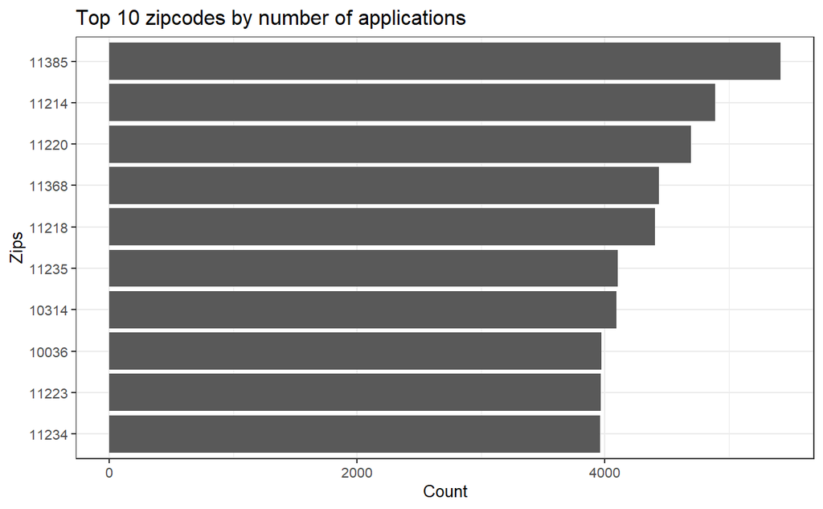

Top 10 zips

## Overall Distribution

```r
df %>%
  ggplot() +
  geom_bar(aes(year(end_date))) +
  theme_bw() +
  xlab("Year") +
  ylab("Count") +
  ggtitle("Number of Applications 2000-2023")
```

### Fig: Distribution

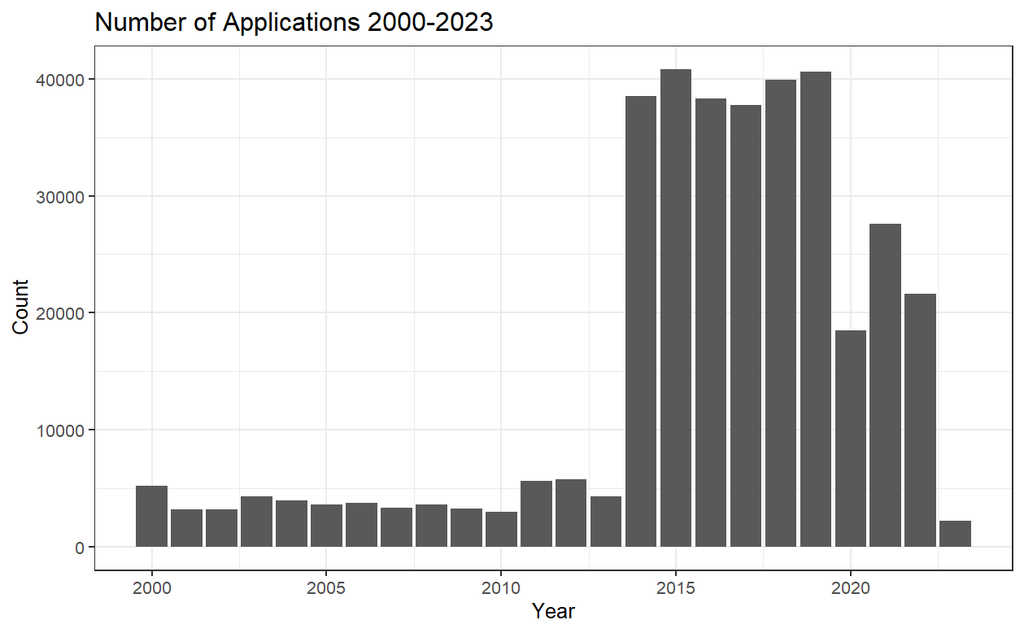

Overall distribution

## What is going on?

As you can see from the table below, the majority of the licenses issued before 2014 regarded the Tobacco shops, and the rest of the categories had very little records.

Either NY passed a law that required businesses to have a license to operate (a hypothesis I could not prove due to the lack of information online) or New Yorkers embarked on what seems to be an entrepreneurial journey that continues to thrive despite Covid-19 pandemic. However, the second option is highly unlikely due to very low number and limited categories as seen in the table

```r
df %>%
  filter(year(end_date) < 2014) %>%
  group_by(license_category) %>%
  summarise(count = n()) %>%
  gt()
```

| license_category | count |
| --- | --- |
| Cabaret | 1 |
| Catering Establishment | 1 |
| Garage | 59 |
| Garage and Parking Lot | 2 |
| General Vendor | 25 |
| Home Improvement Contractor | 2 |
| Home Improvement Salesperson | 4 |
| Laundry | 11 |
| Laundry Jobber | 2 |
| Parking Lot | 6 |
| Secondhand Dealer - Auto | 4 |
| Secondhand Dealer - General | 1 |
| Sidewalk Cafe | 4 |
| Special Sale | 1 |
| Stoop Line Stand | 1 |
| Tobacco Retail Dealer | 55929 |

## Processing Time

The Department of Consumer and Worker Protection (DCWP) seems to be very efficient with the applications since half of the applications are closed only one day after the application is submitted, 75% of applications are closed not later than 3 days, and 98.5% of all the applications is closed within 3 months.

By looking at the table below, we can see in descending order the license categories that take the most time to get processed and issued.

Pedicab businesses take the most time on average to get a license with about 34-35 days to get a license. The second category that takes the longest for a license issued are the Tow Truck companies at 31 days and then the Car Wash businesses at 17 days.

This time is highly possible to be due to applicant submitting an incomplete application and need to retain those documents before the license is issued.

```r
# create the data frame
period <- df %>%
  filter(end_date >= start_date) %>% #some data have a end_date before start_date
  filter(year(end_date) > 2013) %>% #only look at data from 2014 and on
  mutate(days = as.integer(end_date - start_date)) #calculate the days

# Quartiles and min/max
summary(period$days)
```

```
##     Min.  1st Qu.   Median     Mean  3rd Qu.     Max.
##    0.000    1.000    1.000    6.952    3.000 3787.000
```

```r
# % of issued licenses before 3 months = 98.5%
nrow(filter(period, days < 90)) / nrow(period)
```

```
## [1] 0.9855194
```

```r
# table the top 10 slowest
period %>%
  group_by(license_category) %>%
  summarise(days = median(days)) %>%
  arrange(desc(days)) %>%
  top_n(10) %>%
  gt()
```

| license_category | days |
| --- | --- |
| Pedicab Business | 34.5 |
| Tow Truck Company | 31.0 |
| Car Wash | 17.0 |
| Sightseeing Bus | 13.5 |
| Commercial Lessor | 7.0 |
| Laundries | 7.0 |
| Ticket Seller | 7.0 |
| Amusement Arcade | 3.5 |
| Bingo Game Operator | 3.0 |
| Construction Labor Provider | 3.0 |
| Ticket Seller Business | 3.0 |

## Distribution for every year

Below are the graphs from 2014 to 2022 with the total applications submitted for each month (bars-left y axis) and the average timeto process for each month (red line - right y axis). Generally,the distributions are bimodal, which lets us know that the winter months are the busiest for the DCWP.

```r
over_months <- df %>%
  filter(year(start_date) > 2013, year(start_date) < 2023) %>%
  mutate(year = year(start_date), month = month(start_date, label = T)) %>%
  mutate(days = as.integer(end_date - start_date)) %>%
  filter(days > 0) %>%
  group_by(year, month) %>%
  summarise(count = n(), avg = mean(days)) %>%
  ungroup()


over_months %>%
  ggplot() +
  geom_col(aes(x = month, y = count)) +
  geom_line(aes(x = month, y = avg * 100 , group = 1), color = "red") +
  scale_y_continuous("Applications Count",
                     breaks = seq(0, 10000, 2000),
                     sec.axis = sec_axis(~ . /100, name = "Average Days")) +
  facet_wrap(~year) +
  theme_bw() +
  xlab("Month") +
  ggtitle("Year by Year Distribution and Average Processing Time") +
  theme(axis.text.x = element_text(angle = 45))
```

### Fig: Distributions

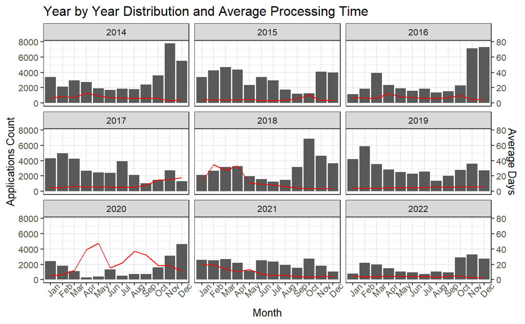

Distributions by year

## Forecasting Until 2025

In this last analysis piece, I fit the data through the Holt-Winter’s exponential smoothing forecasting model with the indent to capture the number of applications in the next 2 years to come. The solid blue line represents the mean, the dark purple area indicates 50% confidence interval and the lighter purple area indicates 90% confidence interval.

```r
dates <- df %>%
  filter(year(end_date) > 2013) %>%
  group_by(year(end_date), month(end_date)) %>%
  summarise(count = n())

dfts <- ts(dates[, 3], start = c(2014, 0), frequency = 12)

autoplot(hw(dfts, h = 24, seasonal = "multiplicative", level = c(50, 90))) +
  theme_bw() +
  xlab("Time") +
  ylab("Application Count") +
  ggtitle("Forecast For The Next 2 Years ")
```

### Fig: Forecast

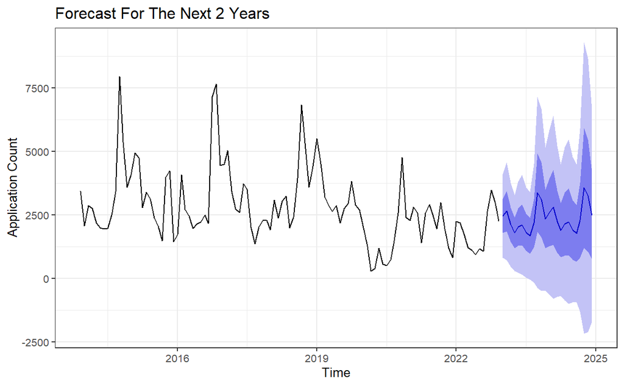

Forecast